# Predicting Professional League of Legends Match Outcomes via Early-Game Performance Metrics: A Case Study on T1

**Name(s)**: Jookyoung Lee

```python
import pandas as pd
import numpy as np
from pathlib import Path

import plotly.express as px
pd.options.plotting.backend = 'plotly'

# from dsc80_utils import * # Feel free to uncomment and use this.
```

```python
df = pd.read_csv('2025_LoL_esports_match_data_from_OraclesElixir.csv')
print(df.head())
```

```
             gameid datacompleteness  url league  year   split  playoffs  \
0  LOLTMNT03_179647         complete  NaN   LFL2  2025  Winter         0
1  LOLTMNT03_179647         complete  NaN   LFL2  2025  Winter         0
2  LOLTMNT03_179647         complete  NaN   LFL2  2025  Winter         0
3  LOLTMNT03_179647         complete  NaN   LFL2  2025  Winter         0
4  LOLTMNT03_179647         complete  NaN   LFL2  2025  Winter         0

                  date  game  patch  ...  opp_csat25 golddiffat25 xpdiffat25  \
0  2025-01-11 11:11:24     1  15.01  ...       200.0        224.0       -1.0
1  2025-01-11 11:11:24     1  15.01  ...       157.0      -2363.0    -1444.0
2  2025-01-11 11:11:24     1  15.01  ...       241.0      -1552.0    -2465.0
3  2025-01-11 11:11:24     1  15.01  ...       257.0      -2613.0    -1156.0
4  2025-01-11 11:11:24     1  15.01  ...        20.0       -662.0     -734.0

  csdiffat25 killsat25 assistsat25 deathsat25  opp_killsat25 opp_assistsat25  \
0       17.0       1.0         1.0        2.0            2.0             4.0
1      -18.0       0.0         1.0        2.0            1.0             7.0
2      -41.0       1.0         0.0        2.0            1.0             5.0
3       -6.0       1.0         1.0        2.0            6.0             2.0
4       18.0       0.0         2.0        2.0            0.0             8.0

  opp_deathsat25
0            2.0
1            0.0
2            1.0
3            0.0
4            0.0

[5 rows x 165 columns]
```

## Step 1: Introduction

Research Question: Using only early-game metrics from the first 10 minutes (e.g., golddiffat10, xpdiffat10, csdiffat10, and killsat10), can we predict whether T1 will win the match?

Faker is a statistical anomaly in esports, making T1 an incredible subject for data analysis because their performance often contradicts standard predictive models through sheer "clutch" consistency.

## Step 2: Data Cleaning and Exploratory Data Analysis

```python
# 1. Filter for Faker
faker_df = df[df['playername'] == 'Faker'].copy()

# 2. THE FIX: Convert 0/1 to 'Loss'/'Win' strings
# This forces Plotly to create a discrete legend instead of a color bar
faker_df['Result'] = faker_df['result'].map({1: 'Win', 0: 'Loss'})

# 3. Create the plot with the new string column
fig = px.scatter(
    faker_df,
    x='earnedgoldshare',
    y='dpm',
    color='Result', # Use the string column here
    symbol='Result',
    hover_name='champion',
    hover_data=['league', 'date', 'damageshare'],
    title='Faker 2025: Gold Efficiency vs. Damage Output',
    labels={
        'earnedgoldshare': 'Share of Team Earned Gold',
        'dpm': 'Damage Per Minute (DPM)'
    },
    template='plotly_dark',
    # Mapping T1 Red for losses and a clean Green for wins
    color_discrete_map={'Win': '#00E676', 'Loss': '#FF4B4B'}
)

fig.update_traces(marker=dict(size=12, opacity=0.8, line=dict(width=1, color='White')))
fig.show()
```

[interactive chart not shown]

**Data Cleaning**

```python
import pandas as pd

# 1. Load the original dataset
df = pd.read_csv('2025_LoL_esports_match_data_from_OraclesElixir.csv', low_memory=False)

# 2. Filter for T1 team rows
# We use position == 'team' to get the 5-player aggregated summary for each game
t1_team = df[(df['teamname'] == 'T1') & (df['position'] == 'team')].copy()

# 3. Format date column properly
t1_team['date'] = pd.to_datetime(t1_team['date'], errors='coerce')

# 4. Define the exact columns needed for your research question
features = ['golddiffat10', 'xpdiffat10', 'csdiffat10', 'killsat10']
target = ['result']
meta = ['gameid', 'date', 'side', 'league']

# 5. Extract only the relevant columns to prevent data leakage from late-game stats
cols_to_keep = meta + target + features
t1_clean = t1_team[cols_to_keep].copy()

# 6. Handle missing values (NaNs)
# Drop any matches where the 10-minute data wasn't recorded
t1_clean = t1_clean.dropna(subset=features)

# 7. Format the target variable for Machine Learning
# Convert result to integer (1 for Win, 0 for Loss)
t1_clean['result'] = t1_clean['result'].astype(int)

# 8. Save the cleaned dataset to a new CSV file
cleaned_filename = 't1_cleaned_early_game_data.csv'
t1_clean.to_csv(cleaned_filename, index=False)

print(f"Cleaned data saved to {cleaned_filename}. Shape: {t1_clean.shape}")
```

```
Cleaned data saved to t1_cleaned_early_game_data.csv. Shape: (187, 9)
```

**Univariate Analysis**

```
Summary Statistics for Early Game Metrics:
       golddiffat10   xpdiffat10  csdiffat10   killsat10
count    187.000000   187.000000  187.000000  187.000000
mean     182.096257   116.561497    5.021390    1.935829
std     1003.453971   806.960526   18.960615    1.727746
min    -1984.000000 -1939.000000  -34.000000    0.000000
25%     -525.500000  -369.500000   -8.000000    1.000000
50%      146.000000    53.000000    3.000000    1.000000
75%      885.000000   630.000000   18.000000    3.000000
max     3707.000000  2652.000000   59.000000    8.000000
```

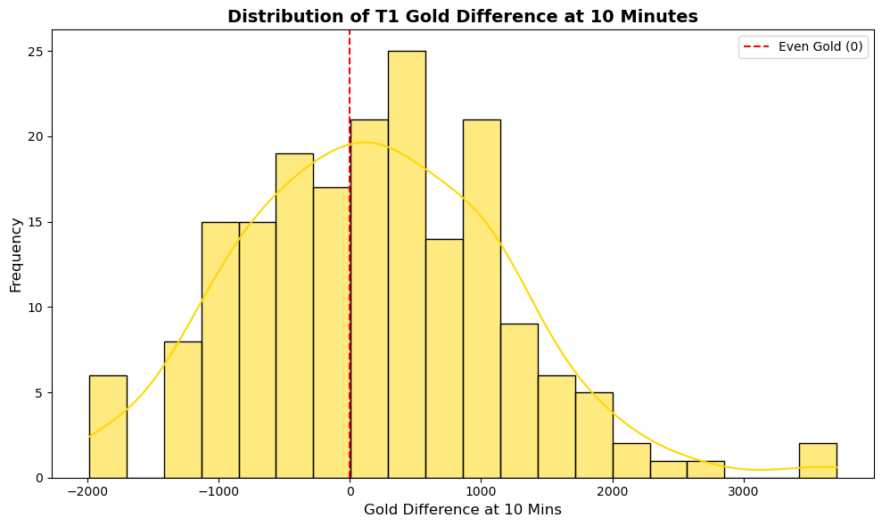

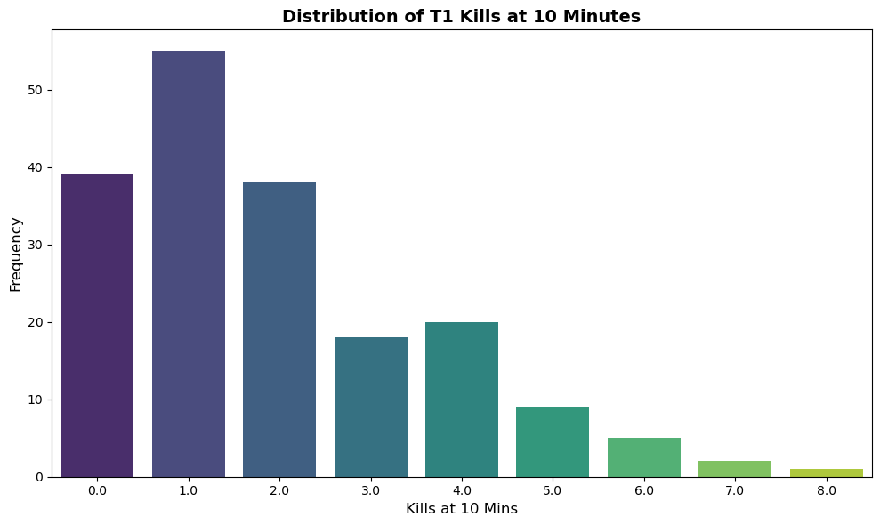

```python
import pandas as pd
import matplotlib.pyplot as plt
import seaborn as sns

# Load the cleaned data
df = pd.read_csv('t1_cleaned_early_game_data.csv')

# ---------------------------------------------------------
# DATAFRAME OPERATIONS: Summary Statistics
# ---------------------------------------------------------
print("Summary Statistics for Early Game Metrics:")
summary_stats = df[['golddiffat10', 'xpdiffat10', 'csdiffat10', 'killsat10']].describe()
print(summary_stats)

# ---------------------------------------------------------
# PLOT 1: Histogram of Gold Difference at 10 Minutes
# ---------------------------------------------------------
plt.figure(figsize=(10, 6))
sns.histplot(df['golddiffat10'], bins=20, kde=True, color='gold')

plt.title('Distribution of T1 Gold Difference at 10 Minutes', fontsize=14, fontweight='bold')
plt.xlabel('Gold Difference at 10 Mins', fontsize=12)
plt.ylabel('Frequency', fontsize=12)
plt.axvline(0, color='red', linestyle='--', label='Even Gold (0)')

plt.legend()
plt.tight_layout()
plt.savefig('univariate_golddiffat10.png') # Saves the image to your folder
plt.show()

# ---------------------------------------------------------
# PLOT 2: Count Plot of Kills at 10 Minutes
# ---------------------------------------------------------
plt.figure(figsize=(10, 6))
sns.countplot(x='killsat10', data=df, palette='viridis')

plt.title('Distribution of T1 Kills at 10 Minutes', fontsize=14, fontweight='bold')
plt.xlabel('Kills at 10 Mins', fontsize=12)
plt.ylabel('Frequency', fontsize=12)

plt.tight_layout()
plt.savefig('univariate_killsat10.png') # Saves the image to your folder
plt.show()
```

**Bivariate Analysis**

```
Correlation Matrix of Early Game Metrics:
              golddiffat10  xpdiffat10  csdiffat10  killsat10
golddiffat10      1.000000    0.702885    0.400243   0.494988
xpdiffat10        0.702885    1.000000    0.582136   0.320226
csdiffat10        0.400243    0.582136    1.000000   0.000206
killsat10         0.494988    0.320226    0.000206   1.000000

Mean Metrics by Match Result (0 = Loss, 1 = Win):
        golddiffat10  xpdiffat10  csdiffat10  killsat10
result
0        -267.130435 -142.550725    2.376812   1.492754
1         444.779661  268.076271    6.567797   2.194915
```

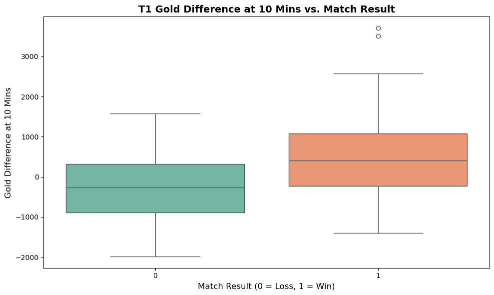

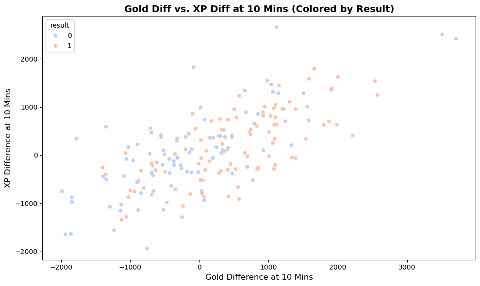

```python
import pandas as pd
import matplotlib.pyplot as plt
import seaborn as sns

# Load the cleaned data
df = pd.read_csv('t1_cleaned_early_game_data.csv')

# ---------------------------------------------------------
# DATAFRAME OPERATIONS: Correlation & Groupby Means
# ---------------------------------------------------------
print("Correlation Matrix of Early Game Metrics:")
corr_matrix = df[['golddiffat10', 'xpdiffat10', 'csdiffat10', 'killsat10']].corr()
print(corr_matrix)

print("\nMean Metrics by Match Result (0 = Loss, 1 = Win):")
groupby_result = df.groupby('result')[['golddiffat10', 'xpdiffat10', 'csdiffat10', 'killsat10']].mean()
print(groupby_result)

# ---------------------------------------------------------
# PLOT 1: Boxplot of Gold Difference vs Result
# ---------------------------------------------------------
fig, ax = plt.subplots(figsize=(10, 6))
sns.boxplot(x='result', y='golddiffat10', data=df, ax=ax, palette='Set2')

ax.set_title('T1 Gold Difference at 10 Mins vs. Match Result', fontsize=14, fontweight='bold')
ax.set_xlabel('Match Result (0 = Loss, 1 = Win)', fontsize=12)
ax.set_ylabel('Gold Difference at 10 Mins', fontsize=12)

plt.tight_layout()
plt.savefig('bivariate_gold_vs_result.png')

# ---------------------------------------------------------
# PLOT 2: Scatterplot of Gold Diff vs XP Diff
# ---------------------------------------------------------
fig, ax = plt.subplots(figsize=(10, 6))
sns.scatterplot(x='golddiffat10', y='xpdiffat10', hue='result', data=df, palette='coolwarm', alpha=0.8, ax=ax)

ax.set_title('Gold Diff vs. XP Diff at 10 Mins (Colored by Result)', fontsize=14, fontweight='bold')
ax.set_xlabel('Gold Difference at 10 Mins', fontsize=12)
ax.set_ylabel('XP Difference at 10 Mins', fontsize=12)

plt.tight_layout()
plt.savefig('bivariate_gold_vs_xp.png')
```

**Interesting Aggregates**

```python
import pandas as pd

# Load the cleaned dataset
df = pd.read_csv('t1_cleaned_early_game_data.csv')

# ---------------------------------------------------------
# 1. GROUPBY: Aggregating by 'side' (Blue vs Red)
# ---------------------------------------------------------
print("=== Mean Early Game Metrics by Side ===")
groupby_side = df.groupby('side')[['golddiffat10', 'xpdiffat10', 'csdiffat10', 'killsat10', 'result']].mean()
print(groupby_side)
print("\n")

# ---------------------------------------------------------
# 2. PIVOT TABLE: Avg Gold Diff at 10 Mins by Side & Result
# ---------------------------------------------------------
print("=== Pivot Table: Avg Gold Diff at 10 by Side & Result ===")
pivot_gold = pd.pivot_table(
    df,
    values='golddiffat10',
    index='side',
    columns='result',
    aggfunc='mean'
)
# Rename columns for clarity
pivot_gold.columns = ['Loss (0)', 'Win (1)']
print(pivot_gold)
print("\n")

# ---------------------------------------------------------
# 3. PIVOT TABLE: Match Count & Win Rate by Side
# ---------------------------------------------------------
print("=== Pivot Table: Match Count by Side & Result ===")
pivot_count = pd.pivot_table(
    df,
    values='gameid',
    index='side',
    columns='result',
    aggfunc='count'
)
pivot_count.columns = ['Losses', 'Wins']

# Create a new column to calculate Win Rate directly in the pivot table!
pivot_count['Win Rate'] = pivot_count['Wins'] / (pivot_count['Losses'] + pivot_count['Wins'])
print(pivot_count)
```

```
=== Mean Early Game Metrics by Side ===
      golddiffat10  xpdiffat10  csdiffat10  killsat10    result
side
Blue    291.397590  148.759036    5.771084   2.024096  0.662651
Red      94.865385   90.865385    4.423077   1.865385  0.605769


=== Pivot Table: Avg Gold Diff at 10 by Side & Result ===
        Loss (0)     Win (1)
side
Blue -124.142857  502.945455
Red  -364.780488  394.000000


=== Pivot Table: Match Count by Side & Result ===
      Losses  Wins  Win Rate
side
Blue      28    55  0.662651
Red       41    63  0.605769
```

## Step 3: Assessment of Missingness

**Missingness Dependency**

```python
import pandas as pd
import numpy as np
import matplotlib.pyplot as plt

# 1. Load the original, full dataset
df = pd.read_csv('2025_LoL_esports_match_data_from_OraclesElixir.csv', low_memory=False)

# Filter to team-level rows to avoid duplicating missingness across 5 players
team_df = df[df['position'] == 'team'].copy()

# Create a boolean column for missingness
team_df['missing_golddiff'] = team_df['golddiffat10'].isnull()

# Helper function to calculate Total Variation Distance (TVD)
def calculate_tvd(data, col, missing_col):
    # Create a normalized distribution table
    dist = data.pivot_table(index=col, columns=missing_col, aggfunc='size', fill_value=0)
    dist = dist / dist.sum() # Normalize column-wise
    # TVD is half the sum of absolute differences
    return np.abs(dist.iloc[:, 0] - dist.iloc[:, 1]).sum() / 2

# ---------------------------------------------------------
# TEST 1: DEPENDENCY ON 'league' (Should Reject Null)
# ---------------------------------------------------------
obs_tvd_league = calculate_tvd(team_df, 'league', 'missing_golddiff')

n_permutations = 500
tvds_league = []

for _ in range(n_permutations):
    # Shuffle the league column
    shuffled_league = team_df['league'].sample(frac=1, replace=False).values
    temp_df = team_df.copy()
    temp_df['league'] = shuffled_league

    # Calculate simulated TVD
    tvds_league.append(calculate_tvd(temp_df, 'league', 'missing_golddiff'))

p_val_league = np.mean(np.array(tvds_league) >= obs_tvd_league)

print(f"--- Missingness vs. League ---")
print(f"Observed TVD: {obs_tvd_league:.4f}")
print(f"P-value: {p_val_league:.4f}")
print("Conclusion: Reject the Null! Missingness DEPENDS on the league.\n")

# ---------------------------------------------------------
# TEST 2: INDEPENDENCE FROM 'side' (Should Fail to Reject Null)
# ---------------------------------------------------------
obs_tvd_side = calculate_tvd(team_df, 'side', 'missing_golddiff')

tvds_side = []

for _ in range(n_permutations):
    # Shuffle the side column
    shuffled_side = team_df['side'].sample(frac=1, replace=False).values
    temp_df = team_df.copy()
    temp_df['side'] = shuffled_side

    # Calculate simulated TVD
    tvds_side.append(calculate_tvd(temp_df, 'side', 'missing_golddiff'))

p_val_side = np.mean(np.array(tvds_side) >= obs_tvd_side)

print(f"--- Missingness vs. Side ---")
print(f"Observed TVD: {obs_tvd_side:.4f}")
print(f"P-value: {p_val_side:.4f}")
print("Conclusion: Fail to Reject the Null. Missingness DOES NOT depend on the side.")
```

```
--- Missingness vs. League ---
Observed TVD: 0.9909
P-value: 0.0000
Conclusion: Reject the Null! Missingness DEPENDS on the league.

--- Missingness vs. Side ---
Observed TVD: 0.0000
P-value: 1.0000
Conclusion: Fail to Reject the Null. Missingness DOES NOT depend on the side.
```

## Step 4: Hypothesis Testing

```
Mean Blue Gold Diff @ 10: 291.40
Mean Red Gold Diff @ 10:  94.87
Observed Difference:      196.53

--- HYPOTHESIS TEST RESULTS ---
Calculated P-value: 0.0944
Result: Fail to Reject the Null Hypothesis.
```

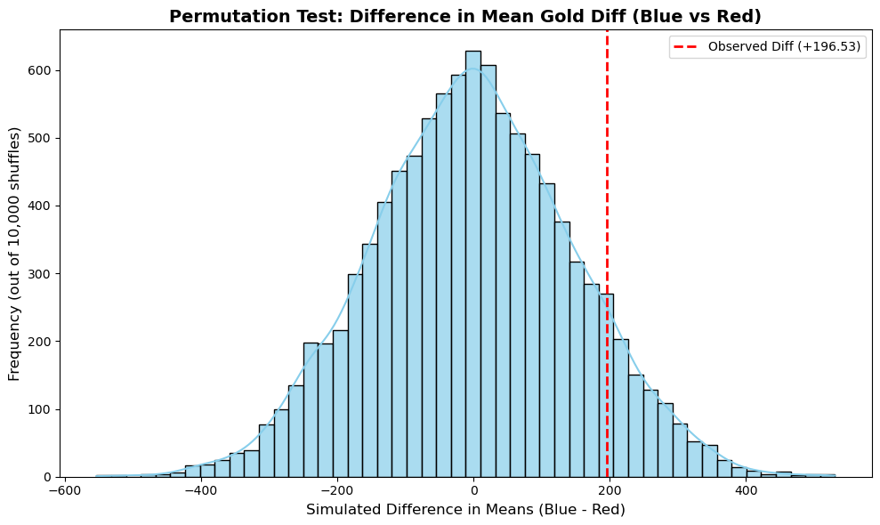

```python
import pandas as pd
import numpy as np
import matplotlib.pyplot as plt
import seaborn as sns

# 1. Load the cleaned early-game dataset
df = pd.read_csv('t1_cleaned_early_game_data.csv')

# 2. Calculate the Observed Test Statistic
mean_blue = df[df['side'] == 'Blue']['golddiffat10'].mean()
mean_red = df[df['side'] == 'Red']['golddiffat10'].mean()
obs_diff = mean_blue - mean_red

print(f"Mean Blue Gold Diff @ 10: {mean_blue:.2f}")
print(f"Mean Red Gold Diff @ 10:  {mean_red:.2f}")
print(f"Observed Difference:      {obs_diff:.2f}")

# 3. Set up the Permutation Test
n_permutations = 10000
simulated_diffs = []

# Extract arrays for speed
gold_diffs = df['golddiffat10'].values
sides = df['side'].values

# Run 10,000 simulations
for _ in range(n_permutations):
    # Randomly shuffle the sides
    shuffled_sides = np.random.permutation(sides)

    # Calculate the simulated difference in means
    sim_blue = gold_diffs[shuffled_sides == 'Blue'].mean()
    sim_red = gold_diffs[shuffled_sides == 'Red'].mean()
    simulated_diffs.append(sim_blue - sim_red)

simulated_diffs = np.array(simulated_diffs)

# 4. Calculate P-Value
p_value = np.mean(simulated_diffs >= obs_diff)

print(f"\n--- HYPOTHESIS TEST RESULTS ---")
print(f"Calculated P-value: {p_value:.4f}")
if p_value < 0.05:
    print("Result: Reject the Null Hypothesis!")
else:
    print("Result: Fail to Reject the Null Hypothesis.")

# 5. Plot the Empirical Distribution
plt.figure(figsize=(10, 6))
sns.histplot(simulated_diffs, bins=50, kde=True, color='skyblue', edgecolor='black', alpha=0.7)

# Draw a red line where our actual observed difference fell
plt.axvline(obs_diff, color='red', linestyle='dashed', linewidth=2,
            label=f'Observed Diff (+{obs_diff:.2f})')

plt.title('Permutation Test: Difference in Mean Gold Diff (Blue vs Red)', fontsize=14, fontweight='bold')
plt.xlabel('Simulated Difference in Means (Blue - Red)', fontsize=12)
plt.ylabel('Frequency (out of 10,000 shuffles)', fontsize=12)
plt.legend()
plt.tight_layout()

plt.show()
```